# Using maps in R

## Exercises and Answers

1. **Using dataset `hills` from `MASS` package, show the linear dependence of distance (`dist`) on time (`time`) and climbing (`climb`) on time. Draw regression lines with data on plot side by side. Predict the `time` value, when `dist` is 25 and `climb` is 6000.**

Proposed answer:

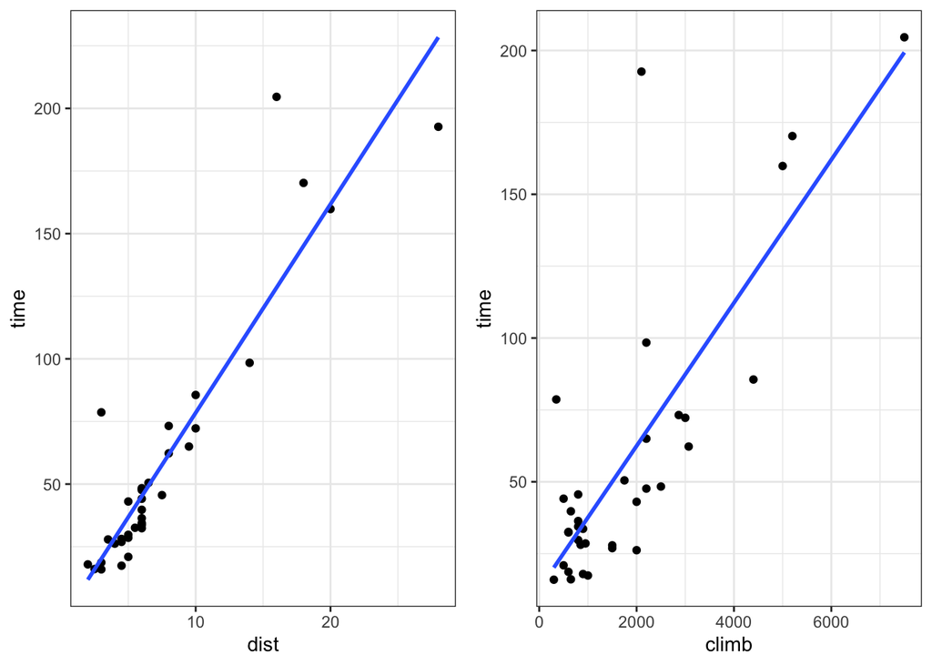

```r
library(MASS)
library(ggplot2)
?hills

# linear regression models
disttime = lm(time ~ dist, data = hills)
climbtime = lm(time ~ climb, data = hills)

plot1 <- ggplot(hills, aes(dist, time))+
  geom_point()+
  geom_smooth(se=F,method = "lm")+
  theme_bw()

plot2 <- ggplot(hills, aes(climb, time))+
  geom_point()+
  geom_smooth(se=F,method = "lm")+
  theme_bw()

gridExtra:: grid.arrange(plot1, plot2, ncol=2)
```

```r
predict(disttime, list(dist = 25))
```

```
##        1
## 203.4207
```

```r
predict(climbtime, list(climb = 6000))
```

```
##        1
## 162.0173
```

2. **Plot a world map which shows PTS score from 2020. Each organization on separate plot.**

Proposed answer:

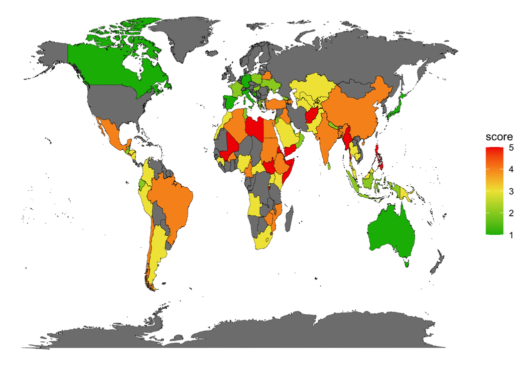

```r
library(ggplot2)
library(readxl)
library(dplyr)
library(tidyr)

PTS <- read_excel("PTS-2021.xlsx",
                  col_types = c("text", "text", "text", "text", "numeric",
                                "text", "numeric", "text", "numeric", "numeric",
                                "numeric", "numeric", "numeric","numeric"))
PTS <- na.omit(PTS)
PTS <- PTS[,c(1,3,9,10,11)]
PTS %>%  pivot_longer(
  cols = starts_with("PTS_"),
  names_to = "Organization",
  names_prefix = "PTS_",
  values_to = "score",
  values_drop_na = TRUE) -> PTS

PTS <- subset(PTS, Year=="2020")

names(PTS)[1] <- "region"

PTSH <- subset(PTS, Organization=="H")

PTSA <- subset(PTS, Organization=="A")

PTSS <- subset(PTS, Organization=="S")

world <- map_data("world")

worldH <- merge(x = world, y = PTSH, by = "region", all.x = TRUE)
worldH <- worldH[order(worldH$order),]

worldA <- merge(x = world, y = PTSA, by = "region", all.x = TRUE)
worldA <- worldA[order(worldA$order),]

worldS <- merge(x = world, y = PTSS, by = "region", all.x = TRUE)
worldS <- worldS[order(worldS$order),]

ggplot() +
  geom_map(
    data = worldH, map = worldH,
    aes(long, lat, map_id = region, fill = score),
    color = "black", size = 0.1) +
  theme_void()+
  scale_fill_gradientn(colors=c("#0CB702","#F0E442","#F21A00"))
```

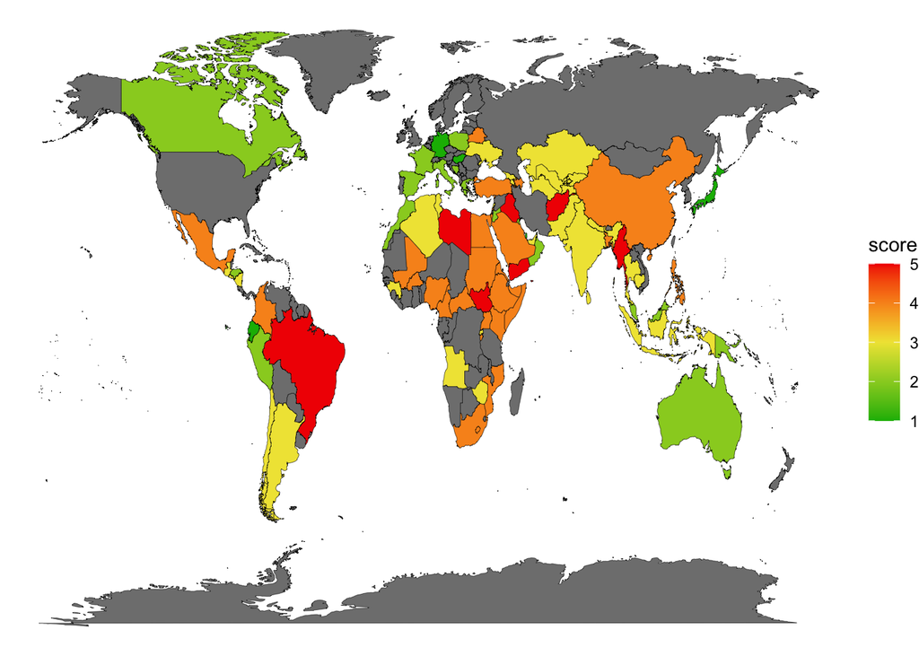

```r
ggplot() +
  geom_map(
    data = worldA, map = worldA,
    aes(long, lat, map_id = region, fill = score),
    color = "black", size = 0.1) +
  theme_void()+
  scale_fill_gradientn(colors=c("#0CB702","#F0E442","#F21A00"))
```

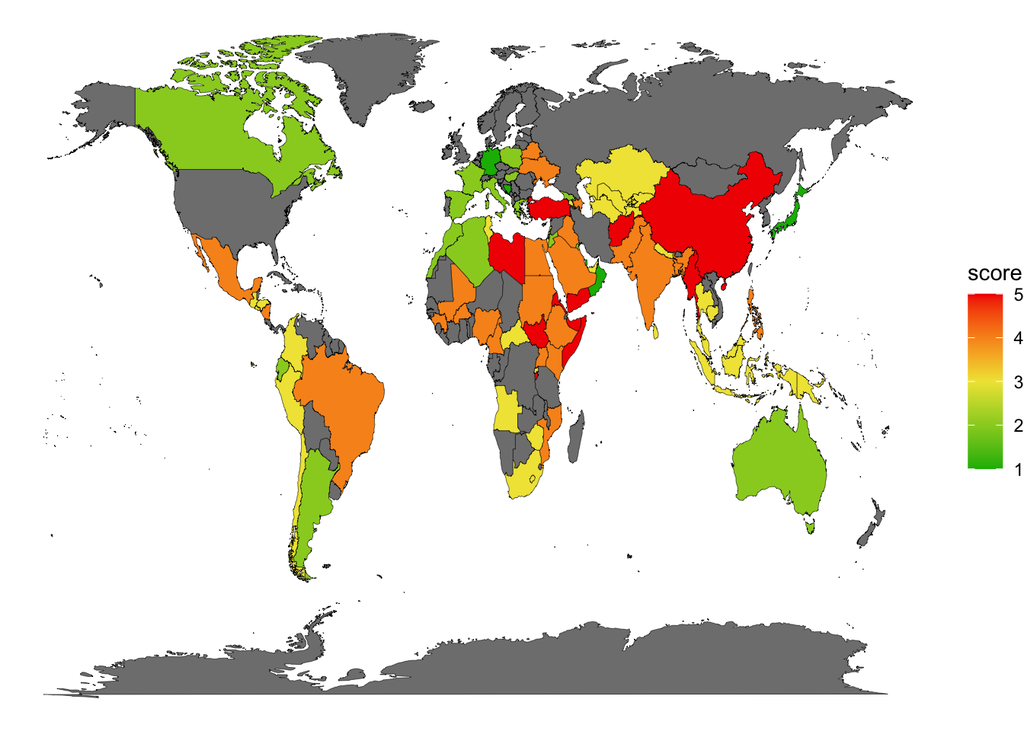

```r
ggplot() +
  geom_map(
    data = worldS, map = worldS,
    aes(long, lat, map_id = region, fill = score),
    color = "black", size = 0.1) +
  theme_void()+
  scale_fill_gradientn(colors=c("#0CB702","#F0E442","#F21A00"))
```

Additional question: Some countries seem to be scored, but they are grey on map. Why?

3. **Plot a world map which shows SVS score from 2016.**

Proposed answer:

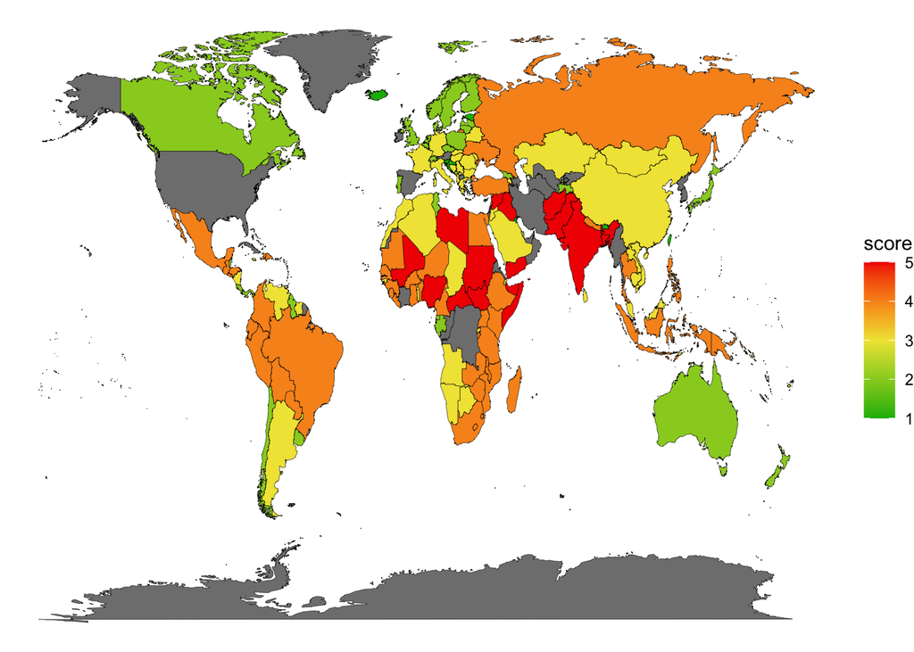

```r
library(stringr)

SVS <- read_excel("SVS 2016 Aggregate.xlsx",
                  col_types = c("skip", "text", "text", "text", "text", "text"))

SVS %>% pivot_longer(
  cols = starts_with("20"),
  names_to = "year",
  values_to = "score",
  values_drop_na = TRUE) -> SVS

SVS$score <- as.numeric(str_remove(SVS$score, "\\*"))

SVS <- na.omit(SVS)

names(SVS)[1] <- "region"

SVS <- subset(SVS, year=="2016")
SVS[35,1] <- "China"
SVS[175,1] <- "UK"

worldSVS <- merge(x = world, y = SVS, by = "region", all.x = TRUE)
worldSVS <- worldSVS[order(worldSVS$order),]

ggplot(worldSVS, aes(long, lat, map_id = region, fill = score)) +
  geom_map(map = worldSVS,
    color = "black", size = 0.1) +
  theme_void()+
  scale_fill_gradientn(colors=c("#0CB702","#F0E442","#F21A00"))
```

Additional question: Some countries seem to be scored, but they are grey on map. Why?

4. **The `votes.repub` dataset from the `cluster` package contains information about the percentage of votes cast for Republicans in U.S. presidential elections from 1856 to 1976. Show on a map how the votes were distributed in 1964 and 1976 and compare them (the graphs must be side by side).**  
   **Note:** **Remember that combining is case sensitive. You can use the `tolower()` function.**  
   **Note:** **To make two graphs side by side you can use the `grid.arrange()` function from the `gridExtra` package.**

Proposed answer:

```r
library(tidyverse)
library(ggplot2)
library(cluster)

# We can see our data
head(votes.repub)
```

```
##            X1856 X1860 X1864 X1868 X1872 X1876 X1880 X1884 X1888 X1892 X1896
## Alabama       NA    NA    NA 51.44 53.19 40.02 36.98 38.44 32.28  3.95 28.13
## Alaska        NA    NA    NA    NA    NA    NA    NA    NA    NA    NA    NA
## Arizona       NA    NA    NA    NA    NA    NA    NA    NA    NA    NA    NA
## Arkansas      NA    NA    NA 53.73 52.17 39.88 39.55 40.50 38.07 32.01 25.11
## California 18.77 32.96 58.63 50.24 56.38 50.88 48.92 52.08 49.95 43.76 49.13
## Colorado      NA    NA    NA    NA    NA    NA 51.28 54.39 55.31 41.13 13.84
##            X1900 X1904 X1908 X1912 X1916 X1920 X1924 X1928 X1932 X1936 X1940
## Alabama    34.67 20.65 24.38  8.26 21.97 30.98 27.01 48.49 14.15 12.82 14.34
## Alaska        NA    NA    NA    NA    NA    NA    NA    NA    NA    NA    NA
## Arizona       NA    NA    NA 12.74 35.37 55.41 41.26 57.57 30.53 26.93 36.01
## Arkansas   35.04 40.25 37.31 19.73 28.01 38.73 29.28 39.33 12.91 17.86 20.87
## California 54.48 61.90 55.46  0.58 46.26 66.24 57.21 64.70 37.40 31.70 41.35
## Colorado   42.04 55.27 46.88 21.88 34.75 59.32 57.02 64.72 41.43 37.09 50.92
##            X1944 X1948 X1952 X1956 X1960 X1964 X1968 X1972 X1976
## Alabama    18.20 19.04 35.02 39.39 41.75  69.5  14.0  72.4 43.48
## Alaska        NA    NA    NA    NA 50.94  34.1  45.3  58.1 62.91
## Arizona    40.90 43.82 58.35 60.99 55.52  50.4  54.8  64.7 58.62
## Arkansas   29.84 21.02 43.76 45.82 43.06  43.9  30.8  68.9 34.97
## California 42.99 47.14 56.39 55.40 50.10  40.9  47.8  55.0 50.89
## Colorado   53.21 46.52 60.27 59.49 54.63  38.7  50.5  62.6 55.89
```

```r
# Save the dataset in a new variable
data <- votes.repub
data$region <- rownames(data)
head(data)
```

```
##            X1856 X1860 X1864 X1868 X1872 X1876 X1880 X1884 X1888 X1892 X1896
## Alabama       NA    NA    NA 51.44 53.19 40.02 36.98 38.44 32.28  3.95 28.13
## Alaska        NA    NA    NA    NA    NA    NA    NA    NA    NA    NA    NA
## Arizona       NA    NA    NA    NA    NA    NA    NA    NA    NA    NA    NA
## Arkansas      NA    NA    NA 53.73 52.17 39.88 39.55 40.50 38.07 32.01 25.11
## California 18.77 32.96 58.63 50.24 56.38 50.88 48.92 52.08 49.95 43.76 49.13
## Colorado      NA    NA    NA    NA    NA    NA 51.28 54.39 55.31 41.13 13.84
##            X1900 X1904 X1908 X1912 X1916 X1920 X1924 X1928 X1932 X1936 X1940
## Alabama    34.67 20.65 24.38  8.26 21.97 30.98 27.01 48.49 14.15 12.82 14.34
## Alaska        NA    NA    NA    NA    NA    NA    NA    NA    NA    NA    NA
## Arizona       NA    NA    NA 12.74 35.37 55.41 41.26 57.57 30.53 26.93 36.01
## Arkansas   35.04 40.25 37.31 19.73 28.01 38.73 29.28 39.33 12.91 17.86 20.87
## California 54.48 61.90 55.46  0.58 46.26 66.24 57.21 64.70 37.40 31.70 41.35
## Colorado   42.04 55.27 46.88 21.88 34.75 59.32 57.02 64.72 41.43 37.09 50.92
##            X1944 X1948 X1952 X1956 X1960 X1964 X1968 X1972 X1976     region
## Alabama    18.20 19.04 35.02 39.39 41.75  69.5  14.0  72.4 43.48    Alabama
## Alaska        NA    NA    NA    NA 50.94  34.1  45.3  58.1 62.91     Alaska
## Arizona    40.90 43.82 58.35 60.99 55.52  50.4  54.8  64.7 58.62    Arizona
## Arkansas   29.84 21.02 43.76 45.82 43.06  43.9  30.8  68.9 34.97   Arkansas
## California 42.99 47.14 56.39 55.40 50.10  40.9  47.8  55.0 50.89 California
## Colorado   53.21 46.52 60.27 59.49 54.63  38.7  50.5  62.6 55.89   Colorado
```

```r
mapdata <- map_data("state")

# The names of the regions vary. We need to change that.
# tolower() function changes uppercase letters to lowercase
data$region %>%
  tolower() -> data$region
head(data)
```

```
##            X1856 X1860 X1864 X1868 X1872 X1876 X1880 X1884 X1888 X1892 X1896
## Alabama       NA    NA    NA 51.44 53.19 40.02 36.98 38.44 32.28  3.95 28.13
## Alaska        NA    NA    NA    NA    NA    NA    NA    NA    NA    NA    NA
## Arizona       NA    NA    NA    NA    NA    NA    NA    NA    NA    NA    NA
## Arkansas      NA    NA    NA 53.73 52.17 39.88 39.55 40.50 38.07 32.01 25.11
## California 18.77 32.96 58.63 50.24 56.38 50.88 48.92 52.08 49.95 43.76 49.13
## Colorado      NA    NA    NA    NA    NA    NA 51.28 54.39 55.31 41.13 13.84
##            X1900 X1904 X1908 X1912 X1916 X1920 X1924 X1928 X1932 X1936 X1940
## Alabama    34.67 20.65 24.38  8.26 21.97 30.98 27.01 48.49 14.15 12.82 14.34
## Alaska        NA    NA    NA    NA    NA    NA    NA    NA    NA    NA    NA
## Arizona       NA    NA    NA 12.74 35.37 55.41 41.26 57.57 30.53 26.93 36.01
## Arkansas   35.04 40.25 37.31 19.73 28.01 38.73 29.28 39.33 12.91 17.86 20.87
## California 54.48 61.90 55.46  0.58 46.26 66.24 57.21 64.70 37.40 31.70 41.35
## Colorado   42.04 55.27 46.88 21.88 34.75 59.32 57.02 64.72 41.43 37.09 50.92
##            X1944 X1948 X1952 X1956 X1960 X1964 X1968 X1972 X1976     region
## Alabama    18.20 19.04 35.02 39.39 41.75  69.5  14.0  72.4 43.48    alabama
## Alaska        NA    NA    NA    NA 50.94  34.1  45.3  58.1 62.91     alaska
## Arizona    40.90 43.82 58.35 60.99 55.52  50.4  54.8  64.7 58.62    arizona
## Arkansas   29.84 21.02 43.76 45.82 43.06  43.9  30.8  68.9 34.97   arkansas
## California 42.99 47.14 56.39 55.40 50.10  40.9  47.8  55.0 50.89 california
## Colorado   53.21 46.52 60.27 59.49 54.63  38.7  50.5  62.6 55.89   colorado
```

```r
# We join tables
mapdata <- left_join(mapdata, data, by = "region")
head(mapdata)
```

```
##        long      lat group order  region subregion X1856 X1860 X1864 X1868
## 1 -87.46201 30.38968     1     1 alabama      <NA>    NA    NA    NA 51.44
## 2 -87.48493 30.37249     1     2 alabama      <NA>    NA    NA    NA 51.44
## 3 -87.52503 30.37249     1     3 alabama      <NA>    NA    NA    NA 51.44
## 4 -87.53076 30.33239     1     4 alabama      <NA>    NA    NA    NA 51.44
## 5 -87.57087 30.32665     1     5 alabama      <NA>    NA    NA    NA 51.44
## 6 -87.58806 30.32665     1     6 alabama      <NA>    NA    NA    NA 51.44
##   X1872 X1876 X1880 X1884 X1888 X1892 X1896 X1900 X1904 X1908 X1912 X1916 X1920
## 1 53.19 40.02 36.98 38.44 32.28  3.95 28.13 34.67 20.65 24.38  8.26 21.97 30.98
## 2 53.19 40.02 36.98 38.44 32.28  3.95 28.13 34.67 20.65 24.38  8.26 21.97 30.98
## 3 53.19 40.02 36.98 38.44 32.28  3.95 28.13 34.67 20.65 24.38  8.26 21.97 30.98
## 4 53.19 40.02 36.98 38.44 32.28  3.95 28.13 34.67 20.65 24.38  8.26 21.97 30.98
## 5 53.19 40.02 36.98 38.44 32.28  3.95 28.13 34.67 20.65 24.38  8.26 21.97 30.98
## 6 53.19 40.02 36.98 38.44 32.28  3.95 28.13 34.67 20.65 24.38  8.26 21.97 30.98
##   X1924 X1928 X1932 X1936 X1940 X1944 X1948 X1952 X1956 X1960 X1964 X1968 X1972
## 1 27.01 48.49 14.15 12.82 14.34  18.2 19.04 35.02 39.39 41.75  69.5    14  72.4
## 2 27.01 48.49 14.15 12.82 14.34  18.2 19.04 35.02 39.39 41.75  69.5    14  72.4
## 3 27.01 48.49 14.15 12.82 14.34  18.2 19.04 35.02 39.39 41.75  69.5    14  72.4
## 4 27.01 48.49 14.15 12.82 14.34  18.2 19.04 35.02 39.39 41.75  69.5    14  72.4
## 5 27.01 48.49 14.15 12.82 14.34  18.2 19.04 35.02 39.39 41.75  69.5    14  72.4
## 6 27.01 48.49 14.15 12.82 14.34  18.2 19.04 35.02 39.39 41.75  69.5    14  72.4
##   X1976
## 1 43.48
## 2 43.48
## 3 43.48
## 4 43.48
## 5 43.48
## 6 43.48
```

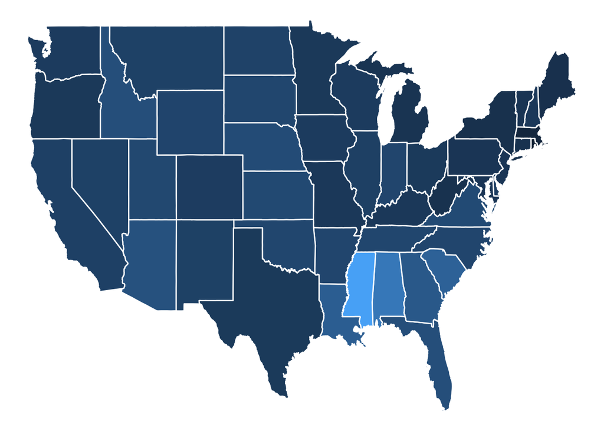

```r
# Let's make sure we don't have any NA in X1964
mapdata1 <- mapdata %>%
  filter(!is.na(mapdata$X1964))

# Let's create a map for the year 1964
map1 <- ggplot(mapdata1,
               aes(x = long, y = lat, group = group, map_id = region)) +
  geom_map(map = mapdata1, aes(fill = X1964),
               color = "white")+theme_void()+theme(legend.position = "none")

map1
```

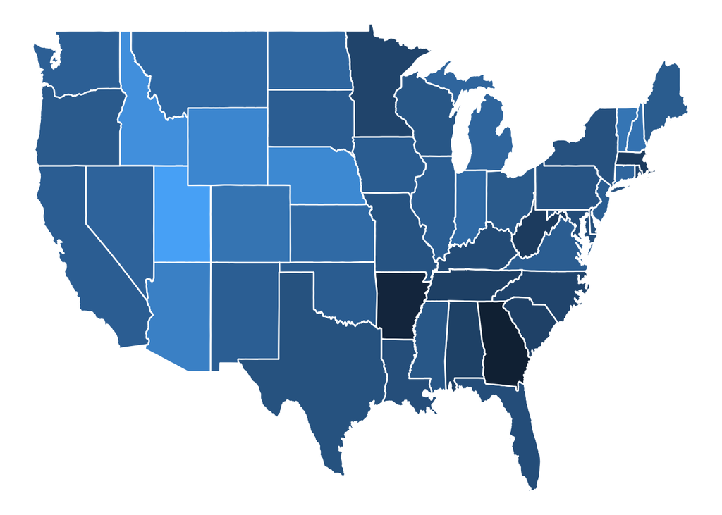

```r
# Same for the year 1976
mapdata2 <- mapdata %>%
  filter(!is.na(mapdata$X1976))

map2 <-ggplot(mapdata2,
              aes(x = long, y = lat, group = group, map_id = region)) +
  geom_map(map = mapdata2, aes(fill = X1976),
               color = "white")+theme_void()+theme(legend.position = "none")

map2
```

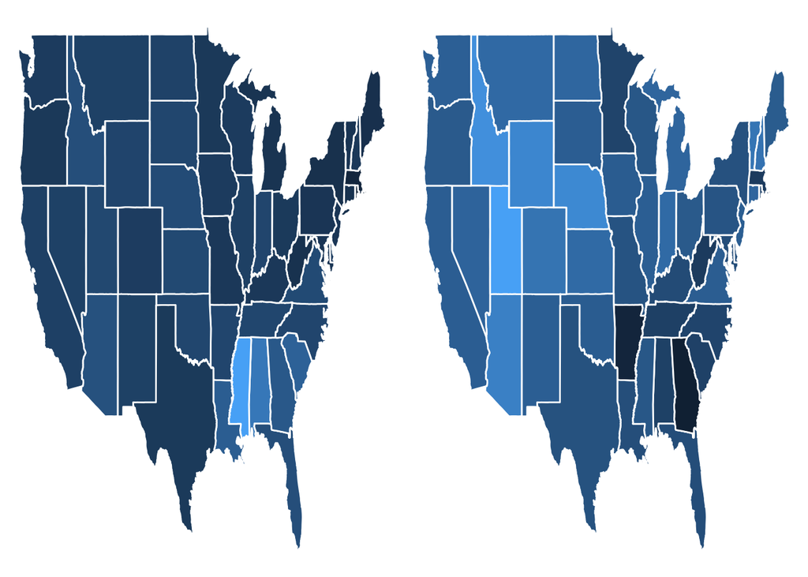

```r
# Side-by-side graphs
library(gridExtra)
grid.arrange(map1, map2, ncol = 2)
```

5. **Load the [dataset](https://covid19.who.int/WHO-COVID-19-global-data.csv). For each country, count the sum of deaths and cases, using the `group_by()` function. Then create a map for the sum of deaths and change the gradient color from yellow to red and remove the axes. Do the same for the sum of cases only change the gradient color from light green to dark green. Mark in gray the countries for which there is no data.**

Proposed answer:

```r
options(scipen = 100, digits = 4)

library(tidyverse)
library(ggplot2)

# Loading a data set
data <- read.csv(url("https://covid19.who.int/WHO-COVID-19-global-data.csv"))
head(data)
```

```
##   Date_reported Country_code     Country WHO_region New_cases Cumulative_cases
## 1    2020-01-03           AF Afghanistan       EMRO         0                0
## 2    2020-01-04           AF Afghanistan       EMRO         0                0
## 3    2020-01-05           AF Afghanistan       EMRO         0                0
## 4    2020-01-06           AF Afghanistan       EMRO         0                0
## 5    2020-01-07           AF Afghanistan       EMRO         0                0
## 6    2020-01-08           AF Afghanistan       EMRO         0                0
##   New_deaths Cumulative_deaths
## 1          0                 0
## 2          0                 0
## 3          0                 0
## 4          0                 0
## 5          0                 0
## 6          0                 0
```

```r
# Counting
data %>%
  group_by(Country) %>%
  summarise(all_cases = sum(New_cases),
            all_deaths = sum(New_deaths)) -> data

# We need to rename a column to join tables
rename(data, region = Country) -> data

head(data)
```

```
## # A tibble: 6 × 3
##   region         all_cases all_deaths
##   <chr>              <int>      <int>
## 1 Afghanistan       181320       7710
## 2 Albania           276821       3497
## 3 Algeria           265952       6875
## 4 American Samoa      6269         31
## 5 Andorra            43449        153
## 6 Angola             99761       1900
```

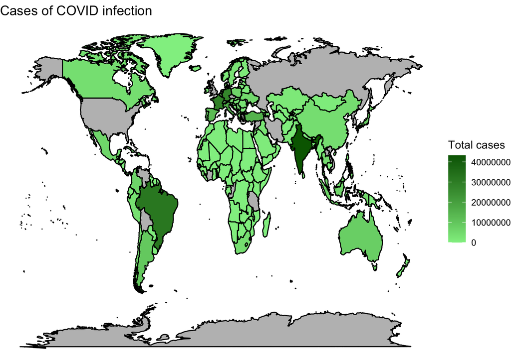

```r
mapdata <-map_data("world")

# Join
mapdata <- left_join(mapdata, data, by = "region")

map1 <- ggplot(mapdata,
               aes(x = long, y = lat, group = group, map_id = region)) +
  geom_map(map = mapdata, aes(fill = all_cases),
               color = "black") +
  scale_fill_gradient(name = "Total cases",
                      low = "lightgreen",
                      high = "darkgreen",
                      na.value = "grey") + # gradient
  theme_void() + # remove axes
  ggtitle("Cases of COVID infection")

map1
```

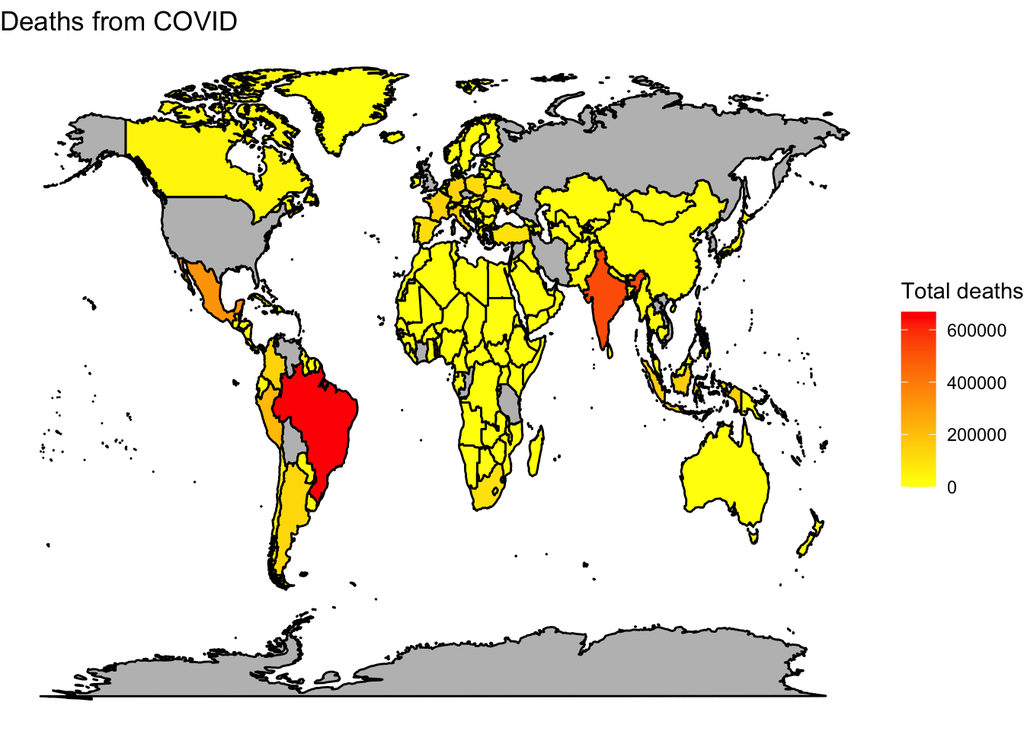

```r
map2 <- ggplot(mapdata,
               aes(x = long, y = lat, group = group, map_id = region)) +
  geom_map(map=mapdata,aes(fill = all_deaths),
               color = "black") +
  scale_fill_gradient(name = "Total deaths",
                      low = "yellow",
                      high = "red",
                      na.value = "grey") +
  theme_void() +
  ggtitle("Deaths from COVID")

map2
```

6. . **`ISLR` package contains dataset `Default` where we have data for 10 000 credit card users. Check out this dataset using `?Default` function. Predict a probability of default when customer is not a student, his balance is 1400 and his income is 2000.**

Proposed answer:

```r
library(ISLR)
?Default

# logistic regression model
model <- glm(default ~ student + balance + income,
             data = Default,
             family = 'binomial')

summary(model)
```

```
##
## Call:
## glm(formula = default ~ student + balance + income, family = "binomial",
##     data = Default)
##
## Deviance Residuals:
##    Min      1Q  Median      3Q     Max
## -2.469  -0.142  -0.056  -0.020   3.738
##
## Coefficients:
##                 Estimate   Std. Error z value            Pr(>|z|)
## (Intercept) -10.86904520   0.49225552  -22.08 <0.0000000000000002 ***
## studentYes   -0.64677581   0.23625253   -2.74              0.0062 **
## balance       0.00573651   0.00023189   24.74 <0.0000000000000002 ***
## income        0.00000303   0.00000820    0.37              0.7115
## ---
## Signif. codes:  0 '***' 0.001 '**' 0.01 '*' 0.05 '.' 0.1 ' ' 1
##
## (Dispersion parameter for binomial family taken to be 1)
##
##     Null deviance: 2920.6  on 9999  degrees of freedom
## Residual deviance: 1571.5  on 9996  degrees of freedom
## AIC: 1580
##
## Number of Fisher Scoring iterations: 8
```

```r
# the best model
model2 <- step(model)
```

```
## Start:  AIC=1580
## default ~ student + balance + income
##
##           Df Deviance  AIC
## - income   1     1572 1578
## <none>           1572 1580
## - student  1     1579 1585
## - balance  1     2907 2913
##
## Step:  AIC=1578
## default ~ student + balance
##
##           Df Deviance  AIC
## <none>           1572 1578
## - student  1     1596 1600
## - balance  1     2909 2913
```

```r
summary(model2)
```

```
##
## Call:
## glm(formula = default ~ student + balance, family = "binomial",
##     data = Default)
##
## Deviance Residuals:
##    Min      1Q  Median      3Q     Max
## -2.458  -0.142  -0.056  -0.020   3.743
##
## Coefficients:
##               Estimate Std. Error z value             Pr(>|z|)
## (Intercept) -10.749496   0.369191  -29.12 < 0.0000000000000002 ***
## studentYes   -0.714878   0.147519   -4.85            0.0000013 ***
## balance       0.005738   0.000232   24.75 < 0.0000000000000002 ***
## ---
## Signif. codes:  0 '***' 0.001 '**' 0.01 '*' 0.05 '.' 0.1 ' ' 1
##
## (Dispersion parameter for binomial family taken to be 1)
##
##     Null deviance: 2920.6  on 9999  degrees of freedom
## Residual deviance: 1571.7  on 9997  degrees of freedom
## AIC: 1578
##
## Number of Fisher Scoring iterations: 8
```

```r
newdata = data.frame(student = "No",
                     balance = 1400)

# probability of defaulting
predict(model2,
        newdata = newdata,
        type = "response")
```

```
##       1
## 0.06203
```